# A COMPARISON OF ENSEMBLE LEARNING METHODS IN RETAIL SALES FORECASTING

**by Serhan SÜER**

# 1. Introduction

Importing libraries:

```python
import pandas as pd
import numpy as np
import seaborn as sns
import matplotlib.pyplot as plt
%matplotlib inline

import time

from math import sqrt
import statistics
from scipy import stats
import category_encoders as ce
import statsmodels.api as sm
from statsmodels.formula.api import ols
from statsmodels.stats.outliers_influence import variance_inflation_factor
from statsmodels.tools.tools import add_constant

from sklearn.preprocessing import LabelEncoder, OneHotEncoder, StandardScaler
from sklearn.feature_selection import VarianceThreshold, SelectKBest, f_regression
from sklearn.model_selection import train_test_split, KFold, GridSearchCV, RandomizedSearchCV
from sklearn.decomposition import PCA

from sklearn.linear_model import LinearRegression
from sklearn.tree import DecisionTreeRegressor
from sklearn.neighbors import KNeighborsRegressor
from sklearn.svm import SVR
from sklearn.svm import libsvm
from sklearn.linear_model import SGDRegressor
from sklearn.ensemble import BaggingRegressor
from sklearn.ensemble import RandomForestRegressor
from sklearn.ensemble import ExtraTreesRegressor
from sklearn.ensemble import AdaBoostRegressor
from sklearn.ensemble import GradientBoostingRegressor
import xgboost as xgb
from sklearn.ensemble import VotingRegressor

from sklearn.metrics import mean_absolute_error, mean_squared_error, r2_score

import warnings
warnings.filterwarnings('ignore')
pd.options.mode.chained_assignment = None
pd.options.display.max_columns = None
pd.set_option('display.float_format', '{:.2f}'.format)
```

Reading the data files:

```python
train = pd.read_csv("data/train.csv", sep=',', header=0,
                    names=['store_id', 'department_id', 'date', 'weekly_sales', 'is_holiday'])

features = pd.read_csv("data/features.csv", sep=',', header=0,
                       names=['store_id', 'date', 'temperature', 'fuel_price', 'markdown_1', 'markdown_2',
                              'markdown_3', 'markdown_4', 'markdown_5', 'cpi', 'unemployment', 'is_holiday'])

stores = pd.read_csv("data/stores.csv", sep=',', header=0,
                     names=['store_id', 'type', 'store_size'])
```

```python
print(train.shape)
print(features.shape)
print(stores.shape)
```

```
(421570, 5)
(8190, 12)
(45, 3)
```

```python
train.head()
```

|  | store_id | department_id | date | weekly_sales | is_holiday |
| --- | --- | --- | --- | --- | --- |
| 0 | 1 | 1 | 2010-02-05 | 24924.50 | False |
| 1 | 1 | 1 | 2010-02-12 | 46039.49 | True |
| 2 | 1 | 1 | 2010-02-19 | 41595.55 | False |
| 3 | 1 | 1 | 2010-02-26 | 19403.54 | False |
| 4 | 1 | 1 | 2010-03-05 | 21827.90 | False |

```python
features.head()
```

|  | store_id | date | temperature | fuel_price | markdown_1 | markdown_2 | markdown_3 | markdown_4 | markdown_5 | cpi | unemployment | is_holiday |
| --- | --- | --- | --- | --- | --- | --- | --- | --- | --- | --- | --- | --- |
| 0 | 1 | 2010-02-05 | 42.31 | 2.57 | nan | nan | nan | nan | nan | 211.10 | 8.11 | False |
| 1 | 1 | 2010-02-12 | 38.51 | 2.55 | nan | nan | nan | nan | nan | 211.24 | 8.11 | True |
| 2 | 1 | 2010-02-19 | 39.93 | 2.51 | nan | nan | nan | nan | nan | 211.29 | 8.11 | False |
| 3 | 1 | 2010-02-26 | 46.63 | 2.56 | nan | nan | nan | nan | nan | 211.32 | 8.11 | False |
| 4 | 1 | 2010-03-05 | 46.50 | 2.62 | nan | nan | nan | nan | nan | 211.35 | 8.11 | False |

```python
stores.head()
```

|  | store_id | type | store_size |
| --- | --- | --- | --- |
| 0 | 1 | A | 151315 |
| 1 | 2 | A | 202307 |
| 2 | 3 | B | 37392 |
| 3 | 4 | A | 205863 |
| 4 | 5 | B | 34875 |

Merging all data files:

```python
data = pd.merge(train, features, on=['store_id', 'date', 'is_holiday'], how='left')
data = pd.merge(data, stores, on=['store_id'], how='left')
del train, features, stores
```

Sorting data by date/store number/department number, moving date column to the beginning and weekly_sales column to the end:

```python
data = data.sort_values(['date', 'store_id', 'department_id']).reset_index(drop=True)
data = pd.concat([data.date, data.drop('date', axis=1)], axis=1)
data = pd.concat([data.drop('weekly_sales', axis=1), data.weekly_sales], axis=1)
```

```python
data.shape
```

```
(421570, 16)
```

The merged data contains 421570 rows and 16 columns.

Looking at the first 5 rows of data:

```python
data.head()
```

|  | date | store_id | department_id | is_holiday | temperature | fuel_price | markdown_1 | markdown_2 | markdown_3 | markdown_4 | markdown_5 | cpi | unemployment | type | store_size | weekly_sales |
| --- | --- | --- | --- | --- | --- | --- | --- | --- | --- | --- | --- | --- | --- | --- | --- | --- |
| 0 | 2010-02-05 | 1 | 1 | False | 42.31 | 2.57 | nan | nan | nan | nan | nan | 211.10 | 8.11 | A | 151315 | 24924.50 |
| 1 | 2010-02-05 | 1 | 2 | False | 42.31 | 2.57 | nan | nan | nan | nan | nan | 211.10 | 8.11 | A | 151315 | 50605.27 |
| 2 | 2010-02-05 | 1 | 3 | False | 42.31 | 2.57 | nan | nan | nan | nan | nan | 211.10 | 8.11 | A | 151315 | 13740.12 |
| 3 | 2010-02-05 | 1 | 4 | False | 42.31 | 2.57 | nan | nan | nan | nan | nan | 211.10 | 8.11 | A | 151315 | 39954.04 |
| 4 | 2010-02-05 | 1 | 5 | False | 42.31 | 2.57 | nan | nan | nan | nan | nan | 211.10 | 8.11 | A | 151315 | 32229.38 |

```python
data.info()
```

```
<class 'pandas.core.frame.DataFrame'>
RangeIndex: 421570 entries, 0 to 421569
Data columns (total 16 columns):
date             421570 non-null object
store_id         421570 non-null int64
department_id    421570 non-null int64
is_holiday       421570 non-null bool
temperature      421570 non-null float64
fuel_price       421570 non-null float64
markdown_1       150681 non-null float64
markdown_2       111248 non-null float64
markdown_3       137091 non-null float64
markdown_4       134967 non-null float64
markdown_5       151432 non-null float64
cpi              421570 non-null float64
unemployment     421570 non-null float64
type             421570 non-null object
store_size       421570 non-null int64
weekly_sales     421570 non-null float64
dtypes: bool(1), float64(10), int64(3), object(2)
memory usage: 48.6+ MB
```

```python
data.apply(lambda x: [x.nunique()])
```

```
date                [143]
store_id             [45]
department_id        [81]
is_holiday            [2]
temperature        [3528]
fuel_price          [892]
markdown_1         [2277]
markdown_2         [1499]
markdown_3         [1662]
markdown_4         [1944]
markdown_5         [2293]
cpi                [2145]
unemployment        [349]
type                  [3]
store_size           [40]
weekly_sales     [359464]
dtype: object
```

```python
data.apply(lambda x: [x.unique()])
```

```
date             [[2010-02-05, 2010-02-12, 2010-02-19, 2010-02-...
store_id         [[1, 2, 3, 4, 5, 6, 7, 8, 9, 10, 11, 12, 13, 1...
department_id    [[1, 2, 3, 4, 5, 6, 7, 8, 9, 10, 11, 12, 13, 1...
is_holiday                                         [[False, True]]
temperature      [[42.31, 40.19, 45.71, 43.76, 39.7, 40.43, 10....
fuel_price       [[2.572, 2.5980000000000003, 2.58, 2.961999999...
markdown_1       [[nan, 10382.9, 10797.64, 8787.59, 12851.52, 2...
markdown_2       [[nan, 6115.67, 20445.0, 2006.62, 16658.47, 19...
markdown_3       [[nan, 215.07, 443.32, 200.01, 430.13, 60.03, ...
markdown_4       [[nan, 2406.62, 4754.07, 570.57, 5630.01, 757....
markdown_5       [[nan, 6551.42, 4787.16, 1005.33, 9213.39, 104...
cpi              [[211.0963582, 210.75260530000003, 214.4248812...
unemployment     [[8.106, 8.324, 7.367999999999999, 8.623, 6.56...
type                                                   [[A, B, C]]
store_size       [[151315, 202307, 37392, 205863, 34875, 202505...
weekly_sales     [[24924.5, 50605.27, 13740.12, 39954.04, 32229...
dtype: object
```

```python
data.isna().mean()
```

```
date            0.00
store_id        0.00
department_id   0.00
is_holiday      0.00
temperature     0.00
fuel_price      0.00
markdown_1      0.64
markdown_2      0.74
markdown_3      0.67
markdown_4      0.68
markdown_5      0.64
cpi             0.00
unemployment    0.00
type            0.00
store_size      0.00
weekly_sales    0.00
dtype: float64
```

# 2. Exploratory Data Analysis

## 2.1. Univariate Analysis

```python
cats = data[['date', 'store_id', 'department_id', 'is_holiday', 'type']]
nums = data.drop(cats.columns, axis=1).fillna(0)
```

### - Categorical

```python
pd.DataFrame({'Categorical Variables':cats.columns})
```

|  | Categorical Variables |
| --- | --- |
| 0 | date |
| 1 | store_id |
| 2 | department_id |
| 3 | is_holiday |
| 4 | type |

```python
def analyze_cats(dataframe, column_name):
    print('-' * 100 + '\n' + 'Number of Unique Values:')
    print(str(dataframe[column_name].nunique()) + '\n' + '-' * 100)
    print('Unique Values:')
    print(np.sort(dataframe[column_name].unique()), '\n' + '-' * 100)
    uniques = list(dataframe[column_name].value_counts().index)
    counts = list(dataframe[column_name].value_counts().values)
    percentages = list(dataframe[column_name].value_counts(normalize=True).values)
    freq_table_list =  list(zip(uniques, counts, percentages))
    freq_table = pd.DataFrame(freq_table_list, columns = [column_name.capitalize(), 'Count' , 'Count%'])
    plt.figure(figsize=(18, 8))
    if len(dataframe[column_name].unique()) < 5:
        display(freq_table, dataframe[column_name].value_counts(normalize = True).plot(kind='pie',
                                                          labels=dataframe[column_name].unique(),
                                                          autopct='%1.1f%%',
                                                          startangle=90))
    else:
        display(freq_table, dataframe[column_name].value_counts(normalize = True).plot(kind='bar', legend=True))
```

**date**

```
----------------------------------------------------------------------------------------------------
Number of Unique Values:
143
----------------------------------------------------------------------------------------------------
Unique Values:
['2010-02-05' '2010-02-12' '2010-02-19' '2010-02-26' '2010-03-05'
 '2010-03-12' '2010-03-19' '2010-03-26' '2010-04-02' '2010-04-09'
 '2010-04-16' '2010-04-23' '2010-04-30' '2010-05-07' '2010-05-14'
 '2010-05-21' '2010-05-28' '2010-06-04' '2010-06-11' '2010-06-18'
 '2010-06-25' '2010-07-02' '2010-07-09' '2010-07-16' '2010-07-23'
 '2010-07-30' '2010-08-06' '2010-08-13' '2010-08-20' '2010-08-27'
 '2010-09-03' '2010-09-10' '2010-09-17' '2010-09-24' '2010-10-01'
 '2010-10-08' '2010-10-15' '2010-10-22' '2010-10-29' '2010-11-05'
 '2010-11-12' '2010-11-19' '2010-11-26' '2010-12-03' '2010-12-10'
 '2010-12-17' '2010-12-24' '2010-12-31' '2011-01-07' '2011-01-14'
 '2011-01-21' '2011-01-28' '2011-02-04' '2011-02-11' '2011-02-18'
 '2011-02-25' '2011-03-04' '2011-03-11' '2011-03-18' '2011-03-25'
 '2011-04-01' '2011-04-08' '2011-04-15' '2011-04-22' '2011-04-29'
 '2011-05-06' '2011-05-13' '2011-05-20' '2011-05-27' '2011-06-03'
 '2011-06-10' '2011-06-17' '2011-06-24' '2011-07-01' '2011-07-08'
 '2011-07-15' '2011-07-22' '2011-07-29' '2011-08-05' '2011-08-12'
 '2011-08-19' '2011-08-26' '2011-09-02' '2011-09-09' '2011-09-16'
 '2011-09-23' '2011-09-30' '2011-10-07' '2011-10-14' '2011-10-21'
 '2011-10-28' '2011-11-04' '2011-11-11' '2011-11-18' '2011-11-25'
 '2011-12-02' '2011-12-09' '2011-12-16' '2011-12-23' '2011-12-30'
 '2012-01-06' '2012-01-13' '2012-01-20' '2012-01-27' '2012-02-03'
 '2012-02-10' '2012-02-17' '2012-02-24' '2012-03-02' '2012-03-09'
 '2012-03-16' '2012-03-23' '2012-03-30' '2012-04-06' '2012-04-13'
 '2012-04-20' '2012-04-27' '2012-05-04' '2012-05-11' '2012-05-18'
 '2012-05-25' '2012-06-01' '2012-06-08' '2012-06-15' '2012-06-22'
 '2012-06-29' '2012-07-06' '2012-07-13' '2012-07-20' '2012-07-27'
 '2012-08-03' '2012-08-10' '2012-08-17' '2012-08-24' '2012-08-31'
 '2012-09-07' '2012-09-14' '2012-09-21' '2012-09-28' '2012-10-05'
 '2012-10-12' '2012-10-19' '2012-10-26']
----------------------------------------------------------------------------------------------------
```

|  | Date | Count | Count% |
| --- | --- | --- | --- |
| 0 | 2011-12-23 | 3027 | 0.01 |
| 1 | 2011-11-25 | 3021 | 0.01 |
| 2 | 2011-12-16 | 3013 | 0.01 |
| 3 | 2011-12-09 | 3010 | 0.01 |
| 4 | 2012-02-17 | 3007 | 0.01 |
| 5 | 2011-12-30 | 3003 | 0.01 |
| 6 | 2012-02-10 | 3001 | 0.01 |
| 7 | 2011-12-02 | 2994 | 0.01 |
| 8 | 2012-03-02 | 2990 | 0.01 |
| 9 | 2012-10-12 | 2990 | 0.01 |
| 10 | 2012-04-06 | 2983 | 0.01 |
| 11 | 2012-02-03 | 2977 | 0.01 |
| 12 | 2012-04-13 | 2977 | 0.01 |
| 13 | 2010-02-19 | 2977 | 0.01 |
| 14 | 2012-10-05 | 2976 | 0.01 |
| 15 | 2012-04-20 | 2975 | 0.01 |
| 16 | 2011-05-06 | 2974 | 0.01 |
| 17 | 2012-03-09 | 2974 | 0.01 |
| 18 | 2012-05-11 | 2973 | 0.01 |
| 19 | 2012-01-06 | 2973 | 0.01 |
| 20 | 2012-09-14 | 2967 | 0.01 |
| 21 | 2011-05-13 | 2967 | 0.01 |
| 22 | 2012-08-03 | 2967 | 0.01 |
| 23 | 2012-01-13 | 2966 | 0.01 |
| 24 | 2012-09-07 | 2966 | 0.01 |
| 25 | 2011-11-11 | 2965 | 0.01 |
| 26 | 2011-10-28 | 2964 | 0.01 |
| 27 | 2012-03-16 | 2964 | 0.01 |
| 28 | 2011-03-11 | 2964 | 0.01 |
| 29 | 2012-08-31 | 2962 | 0.01 |
| ... | ... | ... | ... |
| 113 | 2011-08-05 | 2929 | 0.01 |
| 114 | 2010-11-12 | 2928 | 0.01 |
| 115 | 2011-01-14 | 2928 | 0.01 |
| 116 | 2010-09-03 | 2926 | 0.01 |
| 117 | 2011-02-04 | 2926 | 0.01 |
| 118 | 2010-06-18 | 2925 | 0.01 |
| 119 | 2011-06-10 | 2924 | 0.01 |
| 120 | 2011-07-15 | 2924 | 0.01 |
| 121 | 2010-07-23 | 2923 | 0.01 |
| 122 | 2011-06-03 | 2922 | 0.01 |
| 123 | 2010-05-14 | 2922 | 0.01 |
| 124 | 2010-04-30 | 2920 | 0.01 |
| 125 | 2011-07-29 | 2919 | 0.01 |
| 126 | 2011-01-28 | 2919 | 0.01 |
| 127 | 2011-01-21 | 2918 | 0.01 |
| 128 | 2010-07-30 | 2917 | 0.01 |
| 129 | 2010-07-02 | 2917 | 0.01 |
| 130 | 2010-06-25 | 2917 | 0.01 |
| 131 | 2011-07-22 | 2916 | 0.01 |
| 132 | 2010-11-19 | 2916 | 0.01 |
| 133 | 2010-05-21 | 2911 | 0.01 |
| 134 | 2010-06-04 | 2910 | 0.01 |
| 135 | 2010-06-11 | 2909 | 0.01 |
| 136 | 2010-08-06 | 2908 | 0.01 |
| 137 | 2010-05-28 | 2907 | 0.01 |
| 138 | 2010-07-09 | 2903 | 0.01 |
| 139 | 2010-07-16 | 2901 | 0.01 |
| 140 | 2010-08-20 | 2901 | 0.01 |
| 141 | 2010-08-27 | 2898 | 0.01 |
| 142 | 2010-08-13 | 2896 | 0.01 |

143 rows × 3 columns

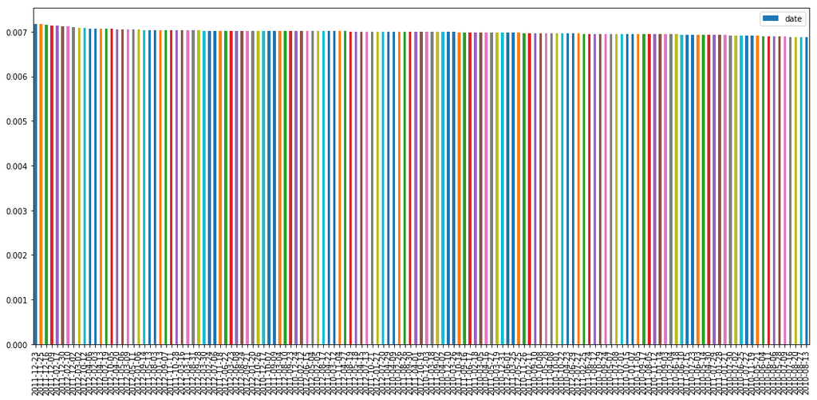

```python
analyze_cats(data, 'date')
```

Dataset consists of weekly sales of Wallmart Stores from 2010-02-05 to 2012-10-26.  
So time period of the data can be considered as 2 years and 9 months or 143 weeks.

**store_id**

```
----------------------------------------------------------------------------------------------------
Number of Unique Values:
45
----------------------------------------------------------------------------------------------------
Unique Values:
[ 1  2  3  4  5  6  7  8  9 10 11 12 13 14 15 16 17 18 19 20 21 22 23 24
 25 26 27 28 29 30 31 32 33 34 35 36 37 38 39 40 41 42 43 44 45]
----------------------------------------------------------------------------------------------------
```

|  | Store_id | Count | Count% |
| --- | --- | --- | --- |
| 0 | 13 | 10474 | 0.02 |
| 1 | 10 | 10315 | 0.02 |
| 2 | 4 | 10272 | 0.02 |
| 3 | 1 | 10244 | 0.02 |
| 4 | 2 | 10238 | 0.02 |
| 5 | 24 | 10228 | 0.02 |
| 6 | 27 | 10225 | 0.02 |
| 7 | 34 | 10224 | 0.02 |
| 8 | 20 | 10214 | 0.02 |
| 9 | 6 | 10211 | 0.02 |
| 10 | 32 | 10202 | 0.02 |
| 11 | 19 | 10148 | 0.02 |
| 12 | 31 | 10142 | 0.02 |
| 13 | 28 | 10113 | 0.02 |
| 14 | 41 | 10088 | 0.02 |
| 15 | 11 | 10062 | 0.02 |
| 16 | 23 | 10050 | 0.02 |
| 17 | 14 | 10040 | 0.02 |
| 18 | 40 | 10017 | 0.02 |
| 19 | 15 | 9901 | 0.02 |
| 20 | 8 | 9895 | 0.02 |
| 21 | 39 | 9878 | 0.02 |
| 22 | 17 | 9864 | 0.02 |
| 23 | 18 | 9859 | 0.02 |
| 24 | 26 | 9854 | 0.02 |
| 25 | 25 | 9804 | 0.02 |
| 26 | 7 | 9762 | 0.02 |
| 27 | 12 | 9705 | 0.02 |
| 28 | 22 | 9688 | 0.02 |
| 29 | 45 | 9637 | 0.02 |
| 30 | 21 | 9582 | 0.02 |
| 31 | 35 | 9528 | 0.02 |
| 32 | 29 | 9455 | 0.02 |
| 33 | 16 | 9443 | 0.02 |
| 34 | 3 | 9036 | 0.02 |
| 35 | 5 | 8999 | 0.02 |
| 36 | 9 | 8867 | 0.02 |
| 37 | 38 | 7362 | 0.02 |
| 38 | 37 | 7206 | 0.02 |
| 39 | 44 | 7169 | 0.02 |
| 40 | 30 | 7156 | 0.02 |
| 41 | 42 | 6953 | 0.02 |
| 42 | 43 | 6751 | 0.02 |
| 43 | 33 | 6487 | 0.02 |
| 44 | 36 | 6222 | 0.01 |

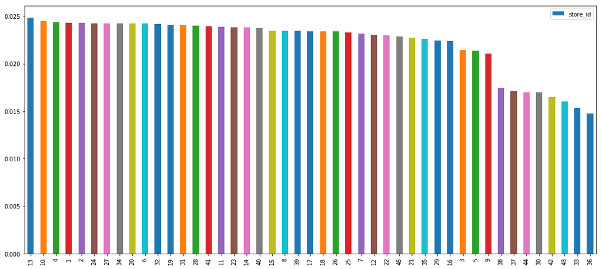

```python
analyze_cats(data, 'store_id')
```

There are 45 Wallmart Stores in the dataset.

**department_id**

```
----------------------------------------------------------------------------------------------------
Number of Unique Values:
81
----------------------------------------------------------------------------------------------------
Unique Values:
[ 1  2  3  4  5  6  7  8  9 10 11 12 13 14 16 17 18 19 20 21 22 23 24 25
 26 27 28 29 30 31 32 33 34 35 36 37 38 39 40 41 42 43 44 45 46 47 48 49
 50 51 52 54 55 56 58 59 60 65 67 71 72 74 77 78 79 80 81 82 83 85 87 90
 91 92 93 94 95 96 97 98 99]
----------------------------------------------------------------------------------------------------
```

|  | Department_id | Count | Count% |
| --- | --- | --- | --- |
| 0 | 1 | 6435 | 0.02 |
| 1 | 10 | 6435 | 0.02 |
| 2 | 38 | 6435 | 0.02 |
| 3 | 21 | 6435 | 0.02 |
| 4 | 67 | 6435 | 0.02 |
| 5 | 16 | 6435 | 0.02 |
| 6 | 14 | 6435 | 0.02 |
| 7 | 13 | 6435 | 0.02 |
| 8 | 79 | 6435 | 0.02 |
| 9 | 81 | 6435 | 0.02 |
| 10 | 46 | 6435 | 0.02 |
| 11 | 82 | 6435 | 0.02 |
| 12 | 8 | 6435 | 0.02 |
| 13 | 90 | 6435 | 0.02 |
| 14 | 91 | 6435 | 0.02 |
| 15 | 92 | 6435 | 0.02 |
| 16 | 7 | 6435 | 0.02 |
| 17 | 4 | 6435 | 0.02 |
| 18 | 95 | 6435 | 0.02 |
| 19 | 3 | 6435 | 0.02 |
| 20 | 2 | 6435 | 0.02 |
| 21 | 40 | 6435 | 0.02 |
| 22 | 11 | 6434 | 0.02 |
| 23 | 74 | 6430 | 0.02 |
| 24 | 17 | 6412 | 0.02 |
| 25 | 12 | 6409 | 0.02 |
| 26 | 42 | 6401 | 0.02 |
| 27 | 87 | 6391 | 0.02 |
| 28 | 9 | 6354 | 0.02 |
| 29 | 25 | 6354 | 0.02 |
| ... | ... | ... | ... |
| 51 | 55 | 5596 | 0.01 |
| 52 | 22 | 5543 | 0.01 |
| 53 | 44 | 5471 | 0.01 |
| 54 | 24 | 5406 | 0.01 |
| 55 | 41 | 5393 | 0.01 |
| 56 | 33 | 5390 | 0.01 |
| 57 | 34 | 5326 | 0.01 |
| 58 | 71 | 5309 | 0.01 |
| 59 | 29 | 5308 | 0.01 |
| 60 | 35 | 5297 | 0.01 |
| 61 | 36 | 5295 | 0.01 |
| 62 | 30 | 5291 | 0.01 |
| 63 | 18 | 5029 | 0.01 |
| 64 | 96 | 4854 | 0.01 |
| 65 | 54 | 4767 | 0.01 |
| 66 | 49 | 4482 | 0.01 |
| 67 | 58 | 4390 | 0.01 |
| 68 | 19 | 4119 | 0.01 |
| 69 | 37 | 2577 | 0.01 |
| 70 | 45 | 1936 | 0.00 |
| 71 | 48 | 1742 | 0.00 |
| 72 | 50 | 1562 | 0.00 |
| 73 | 51 | 1394 | 0.00 |
| 74 | 99 | 862 | 0.00 |
| 75 | 47 | 646 | 0.00 |
| 76 | 78 | 235 | 0.00 |
| 77 | 77 | 150 | 0.00 |
| 78 | 65 | 143 | 0.00 |
| 79 | 39 | 16 | 0.00 |
| 80 | 43 | 12 | 0.00 |

81 rows × 3 columns

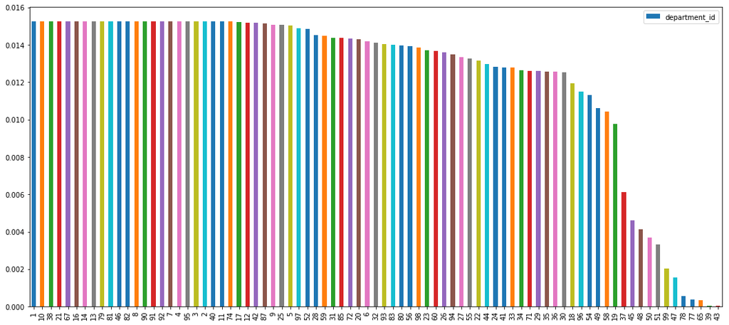

```python
analyze_cats(data, 'department_id')
```

Dataset contains 81 different departments in the stores.  
Furthermore, it can be understood that while some departments exists in most of stores, some exists in only few stores.

**is_holiday**

```
----------------------------------------------------------------------------------------------------
Number of Unique Values:
2
----------------------------------------------------------------------------------------------------
Unique Values:
[False  True]
----------------------------------------------------------------------------------------------------
```

|  | Is_holiday | Count | Count% |
| --- | --- | --- | --- |
| 0 | False | 391909 | 0.93 |
| 1 | True | 29661 | 0.07 |

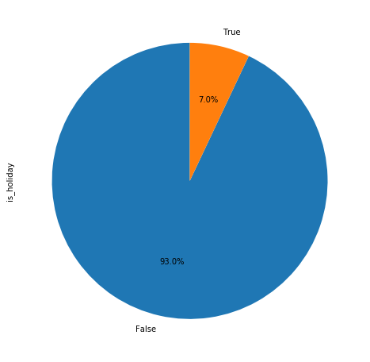

```python
analyze_cats(data, 'is_holiday')
```

The outputs shows that "is_holiday" variable is highly unbalanced since 93% of the weekly sales did not occur in the holidays.

**type**

```
----------------------------------------------------------------------------------------------------
Number of Unique Values:
3
----------------------------------------------------------------------------------------------------
Unique Values:
['A' 'B' 'C']
----------------------------------------------------------------------------------------------------
```

|  | Type | Count | Count% |
| --- | --- | --- | --- |
| 0 | A | 215478 | 0.51 |
| 1 | B | 163495 | 0.39 |
| 2 | C | 42597 | 0.10 |

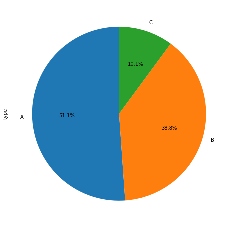

```python
analyze_cats(data, 'type')
```

While roundly half of the weekly sales records are related to Type A stores, almost 40% of them occurred in Type B stores and Type C stores have only 10 percentage.

### - Numerical

```python
pd.DataFrame({'Numerical Variables':nums.columns})
```

|  | Numerical Variables |
| --- | --- |
| 0 | temperature |
| 1 | fuel_price |
| 2 | markdown_1 |
| 3 | markdown_2 |
| 4 | markdown_3 |
| 5 | markdown_4 |
| 6 | markdown_5 |
| 7 | cpi |
| 8 | unemployment |
| 9 | store_size |
| 10 | weekly_sales |

```python
nums.describe()
```

|  | temperature | fuel_price | markdown_1 | markdown_2 | markdown_3 | markdown_4 | markdown_5 | cpi | unemployment | store_size | weekly_sales |
| --- | --- | --- | --- | --- | --- | --- | --- | --- | --- | --- | --- |
| count | 421570.00 | 421570.00 | 421570.00 | 421570.00 | 421570.00 | 421570.00 | 421570.00 | 421570.00 | 421570.00 | 421570.00 | 421570.00 |
| mean | 60.09 | 3.36 | 2590.07 | 879.97 | 468.09 | 1083.13 | 1662.77 | 171.20 | 7.96 | 136727.92 | 15981.26 |
| std | 18.45 | 0.46 | 6052.39 | 5084.54 | 5528.87 | 3894.53 | 4207.63 | 39.16 | 1.86 | 60980.58 | 22711.18 |
| min | -2.06 | 2.47 | 0.00 | -265.76 | -29.10 | 0.00 | 0.00 | 126.06 | 3.88 | 34875.00 | -4988.94 |
| 25% | 46.68 | 2.93 | 0.00 | 0.00 | 0.00 | 0.00 | 0.00 | 132.02 | 6.89 | 93638.00 | 2079.65 |
| 50% | 62.09 | 3.45 | 0.00 | 0.00 | 0.00 | 0.00 | 0.00 | 182.32 | 7.87 | 140167.00 | 7612.03 |
| 75% | 74.28 | 3.74 | 2809.05 | 2.20 | 4.54 | 425.29 | 2168.04 | 212.42 | 8.57 | 202505.00 | 20205.85 |
| max | 100.14 | 4.47 | 88646.76 | 104519.54 | 141630.61 | 67474.85 | 108519.28 | 227.23 | 14.31 | 219622.00 | 693099.36 |

```python
pd.DataFrame({'Features':nums.var().index, 'Variance':nums.var().values}).sort_values('Variance')
```

|  | Features | Variance |
| --- | --- | --- |
| 1 | fuel_price | 0.21 |
| 8 | unemployment | 3.47 |
| 0 | temperature | 340.33 |
| 7 | cpi | 1533.45 |
| 5 | markdown_4 | 15167363.50 |
| 6 | markdown_5 | 17704144.50 |
| 3 | markdown_2 | 25852534.81 |
| 4 | markdown_3 | 30568441.65 |
| 2 | markdown_1 | 36631375.49 |
| 10 | weekly_sales | 515797856.84 |
| 9 | store_size | 3718631543.03 |

```python
pd.DataFrame({'Features':(nums.std() / nums.mean()).index,
              'CV':(nums.std() / nums.mean()).values}).sort_values('CV', ascending=False)
```

|  | Features | CV |
| --- | --- | --- |
| 4 | markdown_3 | 11.81 |
| 3 | markdown_2 | 5.78 |
| 5 | markdown_4 | 3.60 |
| 6 | markdown_5 | 2.53 |
| 2 | markdown_1 | 2.34 |
| 10 | weekly_sales | 1.42 |
| 9 | store_size | 0.45 |
| 0 | temperature | 0.31 |
| 8 | unemployment | 0.23 |
| 7 | cpi | 0.23 |
| 1 | fuel_price | 0.14 |

```python
pd.DataFrame({'Features':nums.skew().index, 'Skewness':nums.skew().values}).sort_values('Skewness')
```

|  | Features | Skewness |
| --- | --- | --- |
| 9 | store_size | -0.33 |
| 0 | temperature | -0.32 |
| 1 | fuel_price | -0.10 |
| 7 | cpi | 0.09 |
| 8 | unemployment | 1.18 |
| 10 | weekly_sales | 3.26 |
| 2 | markdown_1 | 4.73 |
| 5 | markdown_4 | 8.08 |
| 6 | markdown_5 | 9.96 |
| 3 | markdown_2 | 10.65 |
| 4 | markdown_3 | 14.92 |

```python
pd.DataFrame({'Features':nums.kurtosis().index, 'Kurtosis':nums.kurtosis().values}).sort_values('Kurtosis')
```

|  | Features | Kurtosis |
| --- | --- | --- |
| 7 | cpi | -1.83 |
| 9 | store_size | -1.21 |
| 1 | fuel_price | -1.19 |
| 0 | temperature | -0.64 |
| 8 | unemployment | 2.73 |
| 10 | weekly_sales | 21.49 |
| 2 | markdown_1 | 34.92 |
| 5 | markdown_4 | 86.24 |
| 3 | markdown_2 | 145.42 |
| 6 | markdown_5 | 183.41 |
| 4 | markdown_3 | 248.10 |

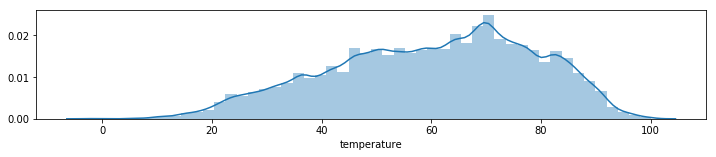

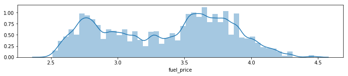

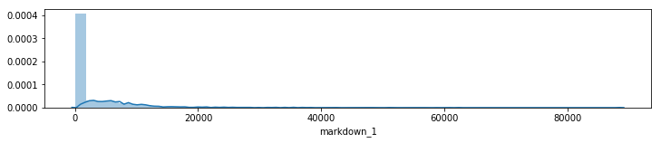

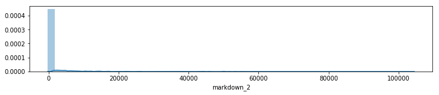

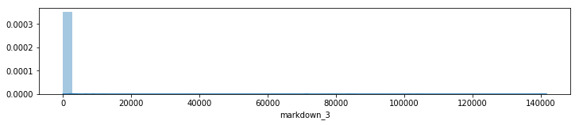

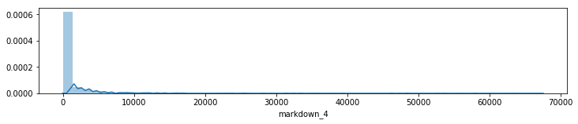

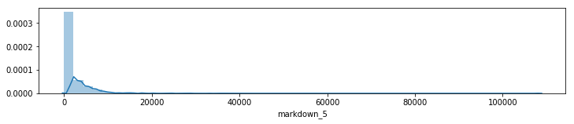

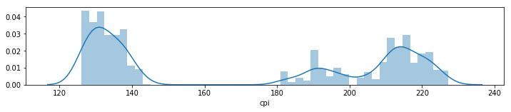

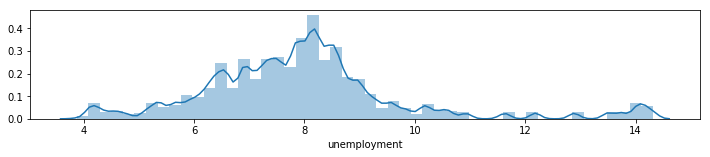

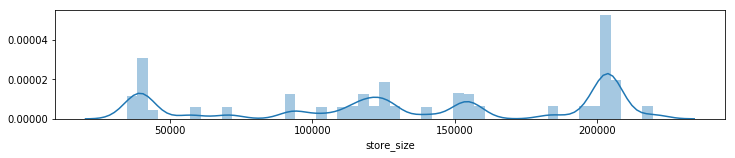

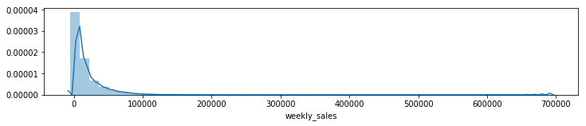

```python
for i in nums.columns:
    plt.figure(figsize=(12, 2))
    sns.distplot(nums[i])
```

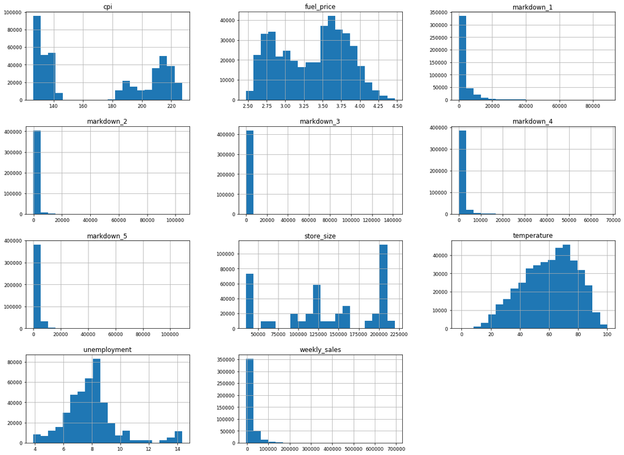

```python
nums.hist(figsize=(20, 15), bins=20, xlabelsize=9, ylabelsize=9);
```

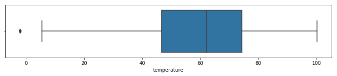

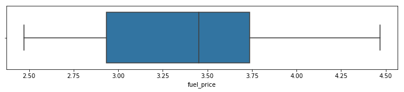

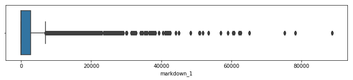

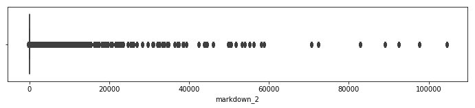

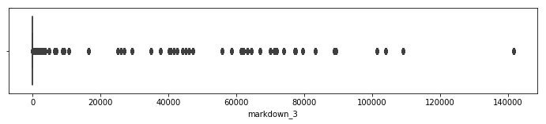

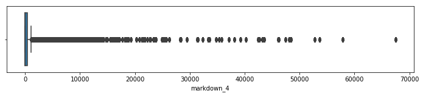

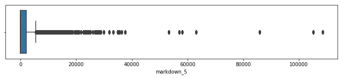

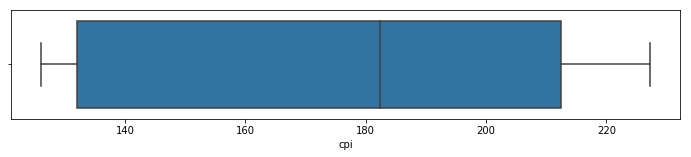

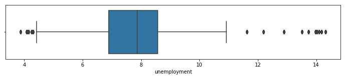

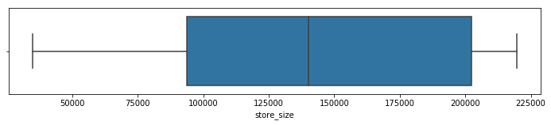

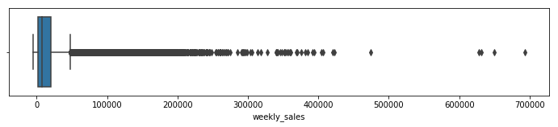

```python
for i in nums.columns:
    plt.figure(figsize=(12, 2))
    sns.boxplot(x=nums[i])
```